# (Prosper Loan Data Exploration)

## Preliminary Wrangling

> This dataset contains data about Prosper, a Credit Company that facilitates peer-to-peer lending. In this dataset there are 113,937 loans in total, with 81 different variables. I have used the following factors to conduct my investigation: Term, LoanStatus, BorrowerRate, ProsperRating (Alpha), ListingCategory (numeric), EmploymentStatus, DelinquenciesLast7Years, StatedMonthlyIncome, TotalProsperLoans, LoanOriginalAmount, LoanOriginationDate, Recommendations, and Investors, they are also some of the terms used by Prosper.

```python
# import all packages and set plots to be embedded inline
import numpy as np
import pandas as pd
import matplotlib.pyplot as plt
import seaborn as sb

%matplotlib inline
```

```python
# Set the grid for the output coulmns and rows
pd.set_option('display.max_rows', None)
pd.set_option('display.max_columns', None)
```

> Load in your dataset and describe its properties through the questions below. Try and motivate your exploration goals through this section.

Adjust the style of the output tables in the notebook to have an outlined edges

```python
%%HTML
<style type="text/css">
table.dataframe td, table.dataframe th {
    border: 1px  black solid !important;
  color: black !important;
}
</style>
```

```python
#lets load in our dataset
loan_temp = pd.read_csv('prosperLoanData.csv')
```

```python
loan_temp.head(5)
```

|  | ListingKey | ListingNumber | ListingCreationDate | CreditGrade | Term | LoanStatus | ClosedDate | BorrowerAPR | BorrowerRate | LenderYield | EstimatedEffectiveYield | EstimatedLoss | EstimatedReturn | ProsperRating (numeric) | ProsperRating (Alpha) | ProsperScore | ListingCategory (numeric) | BorrowerState | Occupation | EmploymentStatus | EmploymentStatusDuration | IsBorrowerHomeowner | CurrentlyInGroup | GroupKey | DateCreditPulled | CreditScoreRangeLower | CreditScoreRangeUpper | FirstRecordedCreditLine | CurrentCreditLines | … |
| --- | --- | --- | --- | --- | --- | --- | --- | --- | --- | --- | --- | --- | --- | --- | --- | --- | --- | --- | --- | --- | --- | --- | --- | --- | --- | --- | --- | --- | --- | --- |
| 0 | 1021339766868145413AB3B | 193129 | 2007-08-26 19:09:29.263000000 | C | 36 | Completed | 2009-08-14 00:00:00 | 0.16516 | 0.1580 | 0.1380 | NaN | NaN | NaN | NaN | NaN | NaN | 0 | CO | Other | Self-employed | 2.0 | True | True | NaN | 2007-08-26 18:41:46.780000000 | 640.0 | 659.0 | 2001-10-11 00:00:00 | 5.0 | … |
| 1 | 10273602499503308B223C1 | 1209647 | 2014-02-27 08:28:07.900000000 | NaN | 36 | Current | NaN | 0.12016 | 0.0920 | 0.0820 | 0.07960 | 0.0249 | 0.05470 | 6.0 | A | 7.0 | 2 | CO | Professional | Employed | 44.0 | False | False | NaN | 2014-02-27 08:28:14 | 680.0 | 699.0 | 1996-03-18 00:00:00 | 14.0 | … |
| 2 | 0EE9337825851032864889A | 81716 | 2007-01-05 15:00:47.090000000 | HR | 36 | Completed | 2009-12-17 00:00:00 | 0.28269 | 0.2750 | 0.2400 | NaN | NaN | NaN | NaN | NaN | NaN | 0 | GA | Other | Not available | NaN | False | True | 783C3371218786870A73D20 | 2007-01-02 14:09:10.060000000 | 480.0 | 499.0 | 2002-07-27 00:00:00 | NaN | … |
| 3 | 0EF5356002482715299901A | 658116 | 2012-10-22 11:02:35.010000000 | NaN | 36 | Current | NaN | 0.12528 | 0.0974 | 0.0874 | 0.08490 | 0.0249 | 0.06000 | 6.0 | A | 9.0 | 16 | GA | Skilled Labor | Employed | 113.0 | True | False | NaN | 2012-10-22 11:02:32 | 800.0 | 819.0 | 1983-02-28 00:00:00 | 5.0 | … |
| 4 | 0F023589499656230C5E3E2 | 909464 | 2013-09-14 18:38:39.097000000 | NaN | 36 | Current | NaN | 0.24614 | 0.2085 | 0.1985 | 0.18316 | 0.0925 | 0.09066 | 3.0 | D | 4.0 | 2 | MN | Executive | Employed | 44.0 | True | False | NaN | 2013-09-14 18:38:44 | 680.0 | 699.0 | 2004-02-20 00:00:00 | 19.0 | … |

```python
# Explore the dataframe size
loan_temp.shape
```

```
(113937, 81)
```

```python
# Check data types of the dataset fields
loan_temp.info()
```

```
<class 'pandas.core.frame.DataFrame'>
RangeIndex: 113937 entries, 0 to 113936
Data columns (total 81 columns):
 #   Column                               Non-Null Count   Dtype
---  ------                               --------------   -----
 0   ListingKey                           113937 non-null  object
 1   ListingNumber                        113937 non-null  int64
 2   ListingCreationDate                  113937 non-null  object
 3   CreditGrade                          28953 non-null   object
 4   Term                                 113937 non-null  int64
 5   LoanStatus                           113937 non-null  object
 6   ClosedDate                           55089 non-null   object
 7   BorrowerAPR                          113912 non-null  float64
 8   BorrowerRate                         113937 non-null  float64
 9   LenderYield                          113937 non-null  float64
```

[output cut: 73 more lines]

```python
# check for duplicates in the dataset
print('There are ', sum(loan_temp.duplicated()), 'amount of duplicates in this dataset')
```

```
There are  0 amount of duplicates in this dataset
```

```python
# Checking for number and percentage of Nulls

# Getting the number of missing values in each column
num_missing = loan_temp.isna().sum()

# Excluding columns that contains 0 missing values
num_missing = num_missing[num_missing > 0]

# Getting the percentages of missing values and round down the result
percent_missing = num_missing * 100 / loan_temp.shape[0]
percent_missing = percent_missing.round(2)

# Concatenating the number and perecentage of missing values
# into one dataframe and sorting it
pd.concat([num_missing, percent_missing], axis=1,
          keys=['Missing Values', 'Percentage']).\
          sort_values(by="Missing Values", ascending=False)
```

|  | Missing Values | Percentage |
| --- | --- | --- |
| GroupKey | 100596 | 88.29 |
| LoanFirstDefaultedCycleNumber | 96985 | 85.12 |
| ScorexChangeAtTimeOfListing | 95009 | 83.39 |
| ProsperPrincipalOutstanding | 91852 | 80.62 |
| ProsperPrincipalBorrowed | 91852 | 80.62 |
| ProsperPaymentsOneMonthPlusLate | 91852 | 80.62 |
| ProsperPaymentsLessThanOneMonthLate | 91852 | 80.62 |
| OnTimeProsperPayments | 91852 | 80.62 |
| TotalProsperPaymentsBilled | 91852 | 80.62 |
| TotalProsperLoans | 91852 | 80.62 |
| CreditGrade | 84984 | 74.59 |
| ClosedDate | 58848 | 51.65 |
| EstimatedEffectiveYield | 29084 | 25.53 |
| EstimatedLoss | 29084 | 25.53 |
| EstimatedReturn | 29084 | 25.53 |
| ProsperRating (numeric) | 29084 | 25.53 |
| ProsperRating (Alpha) | 29084 | 25.53 |
| ProsperScore | 29084 | 25.53 |
| DebtToIncomeRatio | 8554 | 7.51 |
| EmploymentStatusDuration | 7625 | 6.69 |
| AmountDelinquent | 7622 | 6.69 |
| BankcardUtilization | 7604 | 6.67 |
| PublicRecordsLast12Months | 7604 | 6.67 |
| RevolvingCreditBalance | 7604 | 6.67 |
| OpenCreditLines | 7604 | 6.67 |
| CurrentCreditLines | 7604 | 6.67 |
| TradesOpenedLast6Months | 7544 | 6.62 |
| AvailableBankcardCredit | 7544 | 6.62 |
| TotalTrades | 7544 | 6.62 |
| TradesNeverDelinquent (percentage) | 7544 | 6.62 |
| BorrowerState | 5515 | 4.84 |
| Occupation | 3588 | 3.15 |
| EmploymentStatus | 2255 | 1.98 |
| TotalInquiries | 1159 | 1.02 |
| DelinquenciesLast7Years | 990 | 0.87 |
| PublicRecordsLast10Years | 697 | 0.61 |
| CurrentDelinquencies | 697 | 0.61 |
| InquiriesLast6Months | 697 | 0.61 |
| TotalCreditLinespast7years | 697 | 0.61 |
| FirstRecordedCreditLine | 697 | 0.61 |
| CreditScoreRangeUpper | 591 | 0.52 |
| CreditScoreRangeLower | 591 | 0.52 |
| BorrowerAPR | 25 | 0.02 |

I will be interested in certain features of the dataset so, will be removing the nulls for the dataframe containing these features.

```python
# extract the features we need, and rename
sub_data =  [
    'Term', 'LoanStatus', 'BorrowerRate', 'ProsperRating (Alpha)', 'ListingCategory (numeric)', 'EmploymentStatus',
    'DelinquenciesLast7Years', 'StatedMonthlyIncome', 'TotalProsperLoans', 'LoanOriginalAmount',
    'LoanOriginationDate', 'Recommendations', 'Investors'
    ]

# adjust the datframe
loan = loan_temp[sub_data]
```

```python
# explore a sample of the sub dataframe
loan.sample(5)
```

|  | Term | LoanStatus | BorrowerRate | ProsperRating (Alpha) | ListingCategory (numeric) | EmploymentStatus | DelinquenciesLast7Years | StatedMonthlyIncome | TotalProsperLoans | LoanOriginalAmount | LoanOriginationDate | Recommendations | Investors |
| --- | --- | --- | --- | --- | --- | --- | --- | --- | --- | --- | --- | --- | --- |
| 32947 | 36 | Completed | 0.1575 | NaN | 2 | Full-time | 3.0 | 2357.750000 | NaN | 1000 | 2008-04-17 00:00:00 | 0 | 28 |
| 36576 | 36 | Chargedoff | 0.1425 | NaN | 0 | Full-time | 0.0 | 2200.000000 | NaN | 9000 | 2007-06-25 00:00:00 | 1 | 298 |
| 10282 | 36 | Current | 0.0649 | AA | 1 | Employed | 0.0 | 8166.666667 | NaN | 16500 | 2012-02-10 00:00:00 | 0 | 372 |
| 82268 | 36 | Current | 0.2049 | C | 1 | Employed | 0.0 | 7500.000000 | NaN | 10000 | 2013-06-05 00:00:00 | 0 | 51 |
| 80233 | 60 | Current | 0.1028 | AA | 1 | Employed | 0.0 | 5833.333333 | NaN | 17500 | 2012-09-07 00:00:00 | 0 | 183 |

```python
# Check the size of the loan data
loan.shape
```

```
(113937, 13)
```

```python
# Let's check number of null values for the data
missing_values = loan.isnull().sum()

# sort the data
missing_values.sort_values(ascending=False)
```

```
TotalProsperLoans            91852
ProsperRating (Alpha)        29084
EmploymentStatus              2255
DelinquenciesLast7Years        990
Term                             0
LoanStatus                       0
BorrowerRate                     0
ListingCategory (numeric)        0
StatedMonthlyIncome              0
LoanOriginalAmount               0
LoanOriginationDate              0
Recommendations                  0
Investors                        0
dtype: int64
```

```python
# dropping the Nulls from 'ProsperRating (Alpha)'
loan = loan.dropna(subset=['ProsperRating (Alpha)']).reset_index()
```

Lets convert `LoanOriginationDate` to datetime datatype:

```python
# Changing the data type of 'LoanOriginationDate' to datetime
loan['LoanOriginationDate'] = pd.to_datetime(loan['LoanOriginationDate'])
```

```python
# Let's check if there are still nulls
loan.isnull().sum().sort_values(ascending=False)
```

```
TotalProsperLoans            65056
index                            0
Term                             0
LoanStatus                       0
BorrowerRate                     0
ProsperRating (Alpha)            0
ListingCategory (numeric)        0
EmploymentStatus                 0
DelinquenciesLast7Years          0
StatedMonthlyIncome              0
LoanOriginalAmount               0
LoanOriginationDate              0
Recommendations                  0
Investors                        0
dtype: int64
```

According to [data dictionary](https://docs.google.com/spreadsheets/d/1gDyi_L4UvIrLTEC6Wri5nbaMmkGmLQBk-Yx3z0XDEtI/edit#gid=0) The value for column `TotalProsperLoans` will be NaN if there is no past credit history on Prosper, therefore;

Let us replace it with 0:

```python
# Replace 'TotalProsperLoans' Nulls with 0
loan['TotalProsperLoans'] = loan['TotalProsperLoans'].fillna(0)
```

```python
# confirm that there's no Nulls left in the dataset
print ('I can confirm there are', loan.isna().values.sum(), 'nulls left in the loan dataset')
```

```
I can confirm there are 0 nulls left in the loan dataset
```

## Descriptive Statistics

Before going through the analysis, I will check the statistics for the numerical and categorical features of the loan dataframe.

- ### Statistics for the Numerical varibles:

```python
# Get the summary statistics for the numeric values
# exluding 'count' here, as we aleardy know the total count for each varible

loan.describe().transpose()\
    .drop("index", axis=0)
```

|  | count | mean | std | min | 25% | 50% | 75% | max |
| --- | --- | --- | --- | --- | --- | --- | --- | --- |
| Term | 84853.0 | 42.486135 | 11.640346 | 12.00 | 36.0000 | 36.0000 | 60.000000 | 6.000000e+01 |
| BorrowerRate | 84853.0 | 0.196022 | 0.074631 | 0.04 | 0.1359 | 0.1875 | 0.257400 | 3.600000e-01 |
| ListingCategory (numeric) | 84853.0 | 3.312647 | 4.364277 | 0.00 | 1.0000 | 1.0000 | 3.000000 | 2.000000e+01 |
| DelinquenciesLast7Years | 84853.0 | 3.659435 | 9.347957 | 0.00 | 0.0000 | 0.0000 | 2.000000 | 9.900000e+01 |
| StatedMonthlyIncome | 84853.0 | 5931.174803 | 8239.943740 | 0.00 | 3434.0000 | 5000.0000 | 7083.333333 | 1.750003e+06 |
| TotalProsperLoans | 84853.0 | 0.340789 | 0.726235 | 0.00 | 0.0000 | 0.0000 | 0.000000 | 8.000000e+00 |
| LoanOriginalAmount | 84853.0 | 9083.440515 | 6287.860058 | 1000.00 | 4000.0000 | 7500.0000 | 13500.000000 | 3.500000e+04 |
| Recommendations | 84853.0 | 0.017560 | 0.187963 | 0.00 | 0.0000 | 0.0000 | 0.000000 | 1.900000e+01 |
| Investors | 84853.0 | 68.264669 | 95.195831 | 1.00 | 1.0000 | 32.0000 | 97.000000 | 1.189000e+03 |

- ### Statistics for the categorical variables

We'll use the .describe() function to choose the non-numerical columns, and we'll use `np.object` to select the non-numerical columns.

```python
# Get the summary statistics for the non-numeric columns
# exluding 'count' here, as we aleardy know the total count for each varible

loan.describe(include=[np.object]).transpose() \
    .drop('count', axis=1)
```

|  | unique | top | freq |
| --- | --- | --- | --- |
| LoanStatus | 11 | Current | 56576 |
| ProsperRating (Alpha) | 7 | C | 18345 |
| EmploymentStatus | 7 | Employed | 67310 |

### What is the structure of your dataset?

> After cleaning, there are now 84853 for the Loan dataframe as against 113937 loan listings on Prosper, a peer-to-peer credit company. **`LoanStatus`, `BorrowerRate`, `ProsperRating (Alpha)`, `ListingCategory (numeric)`, `EmploymentStatus`, `DelinquenciesLast7Years`, `StatedMonthlyIncome`, `TotalProsperLoans`, `LoanOriginalAmount`, `LoanOriginationDate`, `Recommendations`, `Investors`** are the variables. The majority of the variables are numeric, though there are a few that categorical:
- LoanStatus - categorical variable
- ProsperRating (Aplha) ordinal categorical variable with the following values from higher to lower ('AA', 'A', 'B', 'C', 'D', 'E', 'HR')
- EmploymentStatus - categorical variable
- ListingCategory (numeric) - a numeric code for category of credit (will explored in detail below).
- LoanOriginationDate - datetime object

### What is/are the main feature(s) of interest in your dataset?

> I would want to know what feature(s) are used to predict a default on credit.

> I would want to check what are the major factors that are connected with prosper credit rating.

### What features in the dataset do you think will help support your investigation into your feature(s) of interest?

> I hope that The Prosper rating will have the biggest impact on the chances of a loan default. This might depend on the borrower's income and employment status.

## Univariate Exploration

> In this section, investigate distributions of individual variables. If you see unusual points or outliers, take a deeper look to clean things up and prepare yourself to look at relationships between variables.

> **Rubric Tip**: The project (Parts I alone) should have at least 15 visualizations distributed over univariate, bivariate, and multivariate plots to explore many relationships in the data set. Use reasoning to justify the flow of the exploration.

> **Rubric Tip**: Use the "Question-Visualization-Observations" framework throughout the exploration. This framework involves **asking a question from the data, creating a visualization to find answers, and then recording observations after each visualisation.**

```python
# setting color
color = sb.color_palette()[9]
```

We will look at the `Term` variable, using a Count Plot first:

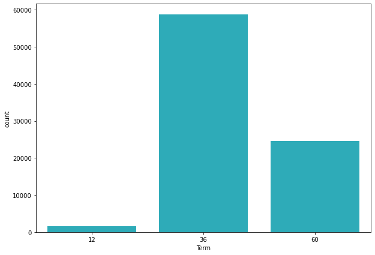

```python
# Visulizing the time periods for loans
plt.figure(figsize = [10, 7])
sb.countplot(data = loan, x = 'Term', color = color);
```

We see there are possibilities for `Term`: the loan durations: 36, 60, and 12 months. The 36-month loan period is the most common in the dataset.

Let's look into `LoanStatus` next:

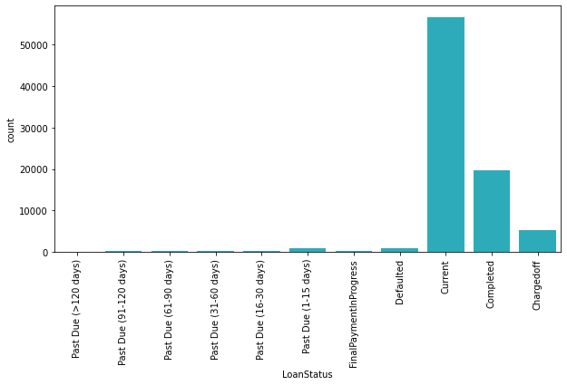

```python
#plt.figure(figsize = [10, 7])
loan_sorted= loan.sort_values('LoanStatus')
#loan_sorted_desc= loan.sort_values('LoanStatus',ascending=True)
loan_sorted= loan.sort_values('LoanStatus',ascending=False)
plt.figure(figsize=[10, 5])
plt.xticks(rotation=90)

sb.countplot(data = loan_sorted, x = 'LoanStatus', color = color);
```

Most of the loans in the dataset are **Current** loans, Followed by the **Completed** loans, **Chargedoff**, respectfully, **Defaulted** and **Past due** categories loans are minority.

We check for `BorrowerRate` next:

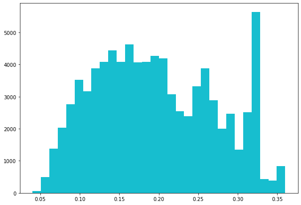

```python
plt.figure(figsize = [10, 7]), plt.hist(data=loan, x='BorrowerRate', bins=30, color = color);
```

The `BorrowerRate` appears to have a bimodal distribution, with a first peak around 0.16 and a larger peak (true mode) about 0.32.

Let's have a look at the amount of Occurrences:

```python
# Check the frequency of the top 2 peaks
loan.BorrowerRate.value_counts().nlargest(2)
```

```
0.3177    3672
0.3199    1645
Name: BorrowerRate, dtype: int64
```

It turns out that the two most common rates are 0.3177 and 0.3199.

Let's check `ProsperRating (Alpha)` next:

Because `ProsperRating (Alpha)` is ordinal categorial variable (From the highest rating A to the lowest HR) We need to convert it using pandas:

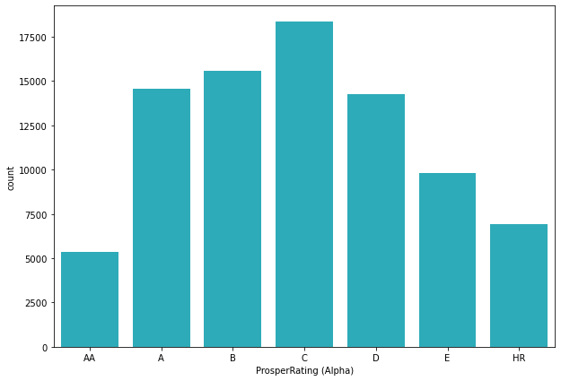

```python
plt.figure(figsize = [10, 7])
ordinal_list = ['AA', 'A', 'B', 'C', 'D', 'E', 'HR']


ordered_var = pd.api.types.CategoricalDtype(ordered = True,
                                                categories = ordinal_list)
loan['ProsperRating (Alpha)'] = loan['ProsperRating (Alpha)'].astype(ordered_var)

#then:
sb.countplot(data=loan, x='ProsperRating (Alpha)', color=color);
```

The ratings are relatively evenly divided, with the highest AA and lowest HR ratings being the least prevalent and the average rating C being the most common.

Next now, the purpose of the loan using `ListingCategory (numeric)`:

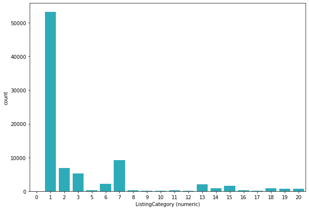

```python
plt.figure(figsize = [10, 7]), sb.countplot(data=loan, x='ListingCategory (numeric)', color=color);
```

When the borrower posted their listing, they chose the following category: 0 - Not Available, 1 - Debt Consolidation, 2 - Home Improvement, 3 - Business, 4 - Personal Loan, 5 - Student Use, 6 - Auto, 7- Other, 8 - Baby&Adoption, 9 - Boat, 10 - Cosmetic Procedure, 11 - Engagement Ring, 12 - Green Loans, 13 - Household Expenses, 14 - Large Purchases, 15 - Medical/Dental, 16 - Motorcycle, 17 - RV, 18 - Taxes, 19 - Vacation, 20 - Wedding Loans

> Debt consolidation is the most common usage of borrowing. Other, Auto, Home Improvement, and Business are also prominent categories.

`EmploymentStatus` is the next variable:

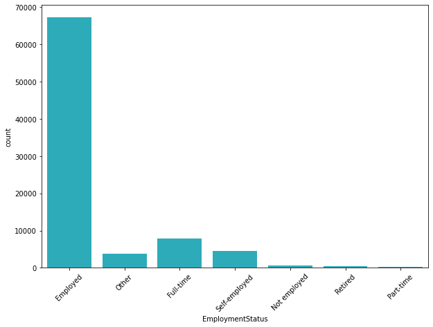

```python
plt.figure(figsize = [10, 7]), sb.countplot(data=loan, x='EmploymentStatus', color=color)
plt.xticks(rotation=45);
```

The majority of borrowers are **Employed**, with the remaining categories accounting for only a minor percentage of the total.

Next is the variable `DelinquenciesLast7Years`:

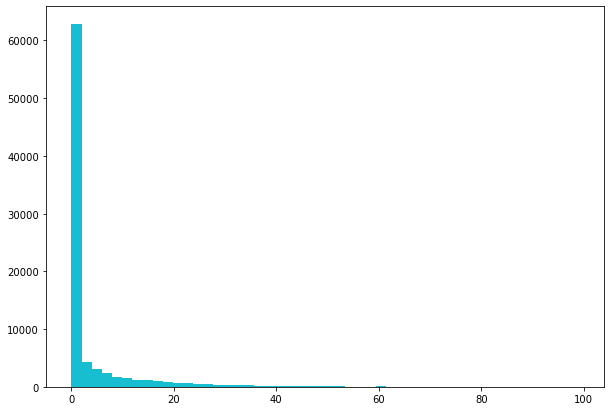

```python
plt.figure(figsize = [10, 7]), plt.hist(data=loan, x='DelinquenciesLast7Years', bins=50, color=color);
```

For the past seven years, the majority of Prosper clients have had **0** delinquencies, a small minority have had up to **20** delinquencies, and a very small group has more than 20 but less than 100 delinquencies.

Next is the `StatedMonthlyIncome`:

Let's check the outliers of the loan data:

```python
# If a data point is far from the mean by more than 3 standard deviations it will be considered an outlier
income_std = loan['StatedMonthlyIncome'].std()
income_mean = loan['StatedMonthlyIncome'].mean()
boundary = income_mean + income_std * 3
print ('There are', len(loan[loan['StatedMonthlyIncome'] >= boundary]), 'outliers')
```

```
There are 245 outliers
```

Let's take a close look at the `StatedMonthlyIncome`:

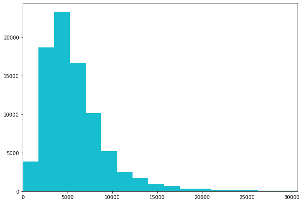

```python
# This time limit x scale by boundary
plt.figure(figsize = [10, 7])
plt.hist(data=loan, x='StatedMonthlyIncome', bins=1000, color=color);
plt.xlim(0, boundary);
```

With a boundary of mean + three standard deviations, the distribution of the monthly income still has noticeable right skew but now we can see that mode is about 5,000.

Next step – `TotalProsperLoans`:

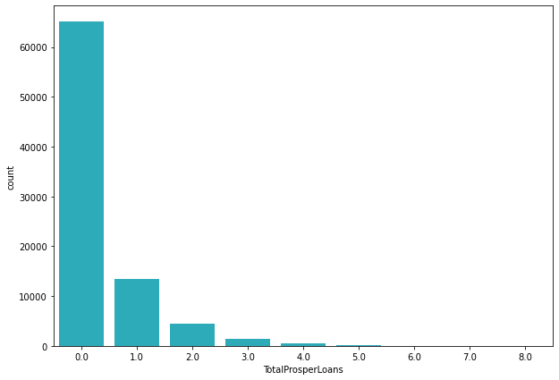

```python
plt.figure(figsize = [10, 7]), sb.countplot(data=loan, x='TotalProsperLoans', color=color);
```

The majority of clients are taking out their first loan with Prosper; however, a tiny percentage of clients have already taken out one, two, or three loans, with a maximum of eight loans.

Next step - `LoanOriginalAmount`:

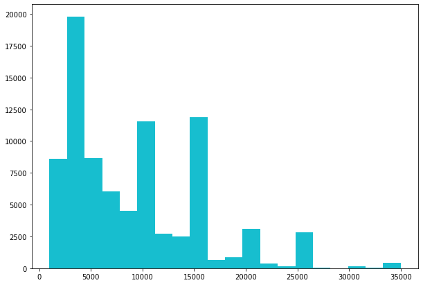

```python
plt.figure(figsize = [10, 7])
plt.hist(data=loan, x='LoanOriginalAmount', bins=20, color=color);
```

It looks like most of the loans are below 15,000 range and people often borrow in increments of 5 thousands i.e. 5000, 10000, 15000, 20000 etc.

Next is `LoanOriginationDate`:

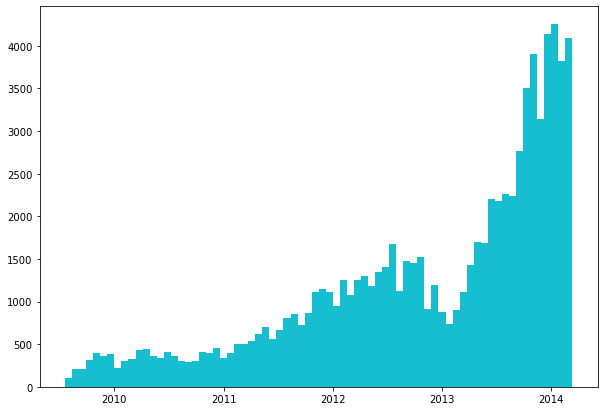

```python
plt.figure(figsize = [10, 7])
plt.hist(data=loan, x='LoanOriginationDate', bins=72, color=color);
```

```python
loan['LoanOriginationDate'].describe()
```

```
count                   84853
unique                   1165
top       2014-01-22 00:00:00
freq                      491
first     2009-07-20 00:00:00
last      2014-03-12 00:00:00
Name: LoanOriginationDate, dtype: object
```

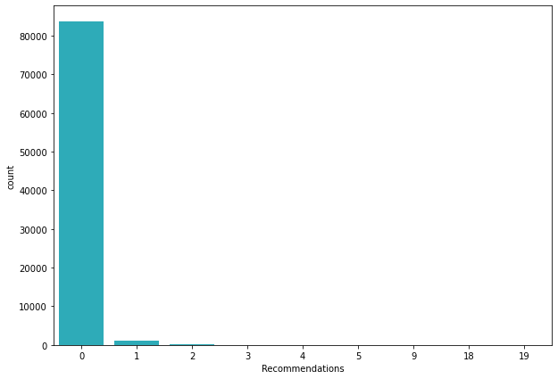

```python
plt.figure(figsize = [10, 7])
sb.countplot(data=loan, x='Recommendations', color=color);
```

The great majority of loans were secured without the need for recommendations.

Next is `Investors`:

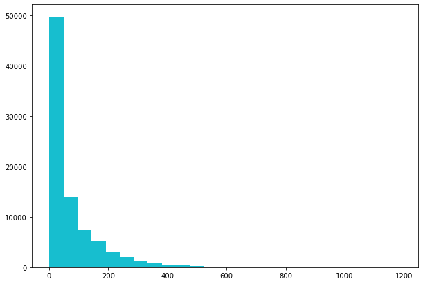

```python
plt.figure(figsize = [10, 7])
plt.hist(data=loan, x='Investors', bins=25, color=color);
```

### Discuss the distribution(s) of your variable(s) of interest. Were there any unusual points? Did you need to perform any transformations?

> The distribution of Prosper ratings is roughly normally distributed. Because this is obviously based on borrowers' self-reporting, there are a lot of outliers and a wide range of numbers, I believe there are a lot of erroneous values, therefore we will into this. I didn't think any scale transformations would be useful in this situation. The majority of loans are under $15,000, and it appears that the majority of loans are in 5,000-dollar increments.

### Of the features you investigated, were there any unusual distributions? Did you perform any operations on the data to tidy, adjust, or change the form of the data? If so, why did you do this?

> The vast majority of loans are current ones. We are not interested in any current loans (or loans with a specified past due time), and chargedoff loans can be regarded defaulted because our major purpose is to define driving elements of loan outcome. In the next stage, we'll make some changes to the data:

```python
# Check the number of each value in the 'LoanStatus'
loan['LoanStatus'].value_counts()
```

```
Current                   56576
Completed                 19664
Chargedoff                 5336
Defaulted                  1005
Past Due (1-15 days)        806
Past Due (31-60 days)       363
Past Due (61-90 days)       313
Past Due (91-120 days)      304
Past Due (16-30 days)       265
FinalPaymentInProgress      205
Past Due (>120 days)         16
Name: LoanStatus, dtype: int64
```

```python
# leaving only completed chargedoff or defaulted listings
condition = (loan['LoanStatus'] == 'Completed') | (loan['LoanStatus'] == 'Defaulted') | (loan['LoanStatus'] == 'Chargedoff')
loan = loan[condition]

# setting chargedoff as defaulted
def change_to_defaulted(row):
    if row['LoanStatus'] == 'Chargedoff':
        return 'Defaulted'
    else:
        return row['LoanStatus']
#then
loan['LoanStatus'] = loan.apply(change_to_defaulted, axis=1)
#Check the values counts again
loan['LoanStatus'].value_counts()
```

```
Completed    19664
Defaulted     6341
Name: LoanStatus, dtype: int64
```

We now have 19664 completed loans and 6341 defaulted loans.

Because `ListingCategory (numeric)` is set up as numeric and most of the values have a very low frequency, we need modify it to categorical and reduce the number of categories for easier visualisation:

```python
# helper function:
categories = {1: 'Debt Consolidation', 2: 'Home Improvement', 3: 'Business', 6: 'Auto', 7: 'Other'}
def reduce_categories(row):
    loan_category = row['ListingCategory (numeric)']
    if  loan_category in categories:
        return categories[loan_category]
    else:
        return categories[7]
```

```python
loan['ListingCategory (numeric)'] = loan.apply(reduce_categories, axis=1)
```

```python
loan['ListingCategory (numeric)'].value_counts()
```

```
Debt Consolidation    12740
Other                  7083
Home Improvement       2612
Business               2366
Auto                   1204
Name: ListingCategory (numeric), dtype: int64
```

We also need to eliminate the outliers from `StatedMonthlyIncome`; we may assume that this is a self-reporting parameter and that the outliers are merely borrowers' errors, with monthly income being misunderstood for yearly income most likely.

```python
# eliminate the outliers
loan = loan[loan['StatedMonthlyIncome'] < boundary]
```

## Bivariate Exploration

We start with the pair-wise correlation between all numeric variables:

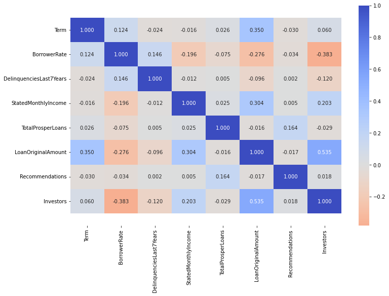

```python
# extract the numerical varibles
numeric_vars = ['Term', 'BorrowerRate', 'DelinquenciesLast7Years', 'StatedMonthlyIncome',
                'TotalProsperLoans', 'LoanOriginalAmount', 'Recommendations', 'Investors'
               ]
# settings of the heatmap
plt.figure(figsize = [12, 8])
ax = sb.heatmap(loan[numeric_vars].corr(), annot = True, fmt = '.3f',
           cmap = 'coolwarm_r', center = 0)

# adjust the cutted edges of the heatmap
bottom, top = ax.get_ylim()
ax.set_ylim(bottom + 0.5, top - 0.5);
```

- There is no strong correlation between variables.
- There are some moderate positive correlation between `LoanOriginalAmount` and `Term`, `LoanOriginalAmount` and number of `Investors`, `LoanOriginalAmount` and `StatedMonthlyIncome`, `Recommendations` and `TotalProsperLoans`, number of delinquencies and borrowers rate.
- Moderate negative correlation between the loan amount and the borrower rate, as well as the number of investors and the borrower rate.

we now check the categorical features:

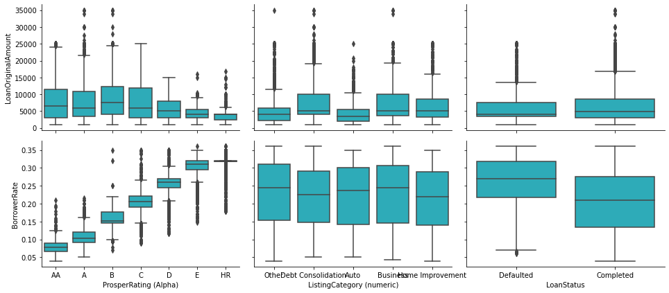

```python
numeric_vars = ['LoanOriginalAmount', 'BorrowerRate']
categoric_vars = ['ProsperRating (Alpha)', 'ListingCategory (numeric)', 'LoanStatus']


def boxgrid(x, y, **kwargs):
    """ Quick hack for creating box plots with seaborn's PairGrid. """
    sb.boxplot(x, y, color = color)

plt.figure(figsize = [10, 10])
g = sb.PairGrid(data = loan, y_vars = numeric_vars, x_vars = categoric_vars,
                 height = 3,aspect = 1.5)
g.map(boxgrid);
plt.show();
```

Borrowers with a poor credit rating are given a smaller loan amount and a higher interest rate. The amount borrowed for 'other' and 'auto' purposes is usually less than for other categories, and the interest rate does not vary considerably between them. Defaulted loans are often smaller than Completed loans. The defaulted loan borrower rate is significantly greater than the completed loan borrower rate, although this is due to consumers with weaker credit ratings paying higher interest rates.

Let's look at what factors can influence a credit decision, starting with Listing Category:

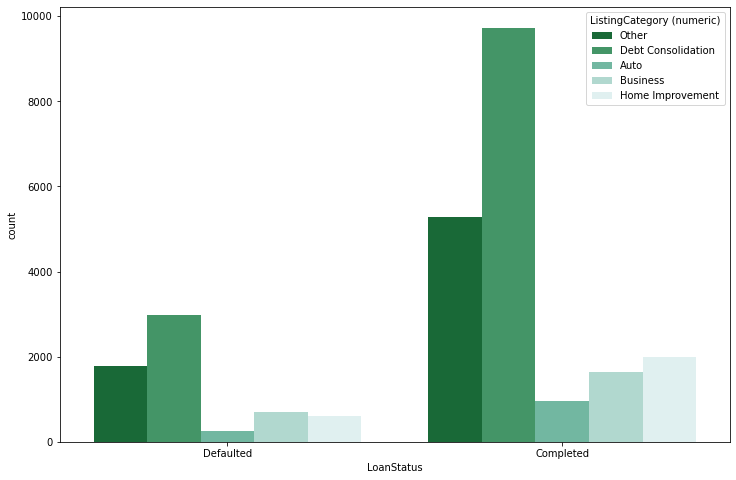

```python
plt.figure(figsize = [12, 8])
sb.countplot(data=loan, x='LoanStatus', hue='ListingCategory (numeric)', palette='BuGn_r');
```

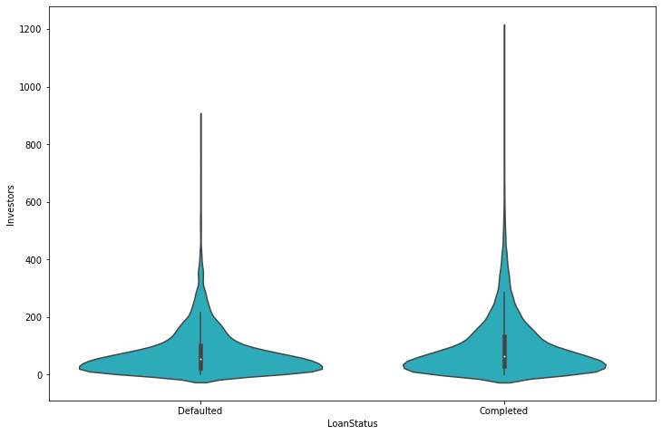

```python
plt.figure(figsize = [12, 8])
sb.violinplot(data = loan, x = 'LoanStatus', y = 'Investors', color = color);
```

Defaulted credits typically have a smaller number of investors.

The relationship between employment and loan status:

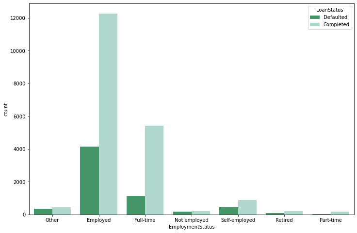

```python
plt.figure(figsize = [12, 8])
sb.countplot(data=loan, x='EmploymentStatus', hue='LoanStatus', palette='BuGn_r');
```

We can see that debtors with the employment statuses of "Not Employed" and "Self-employed" appear to be more likely to default on credit.

We can check the loan status and the loan amount:

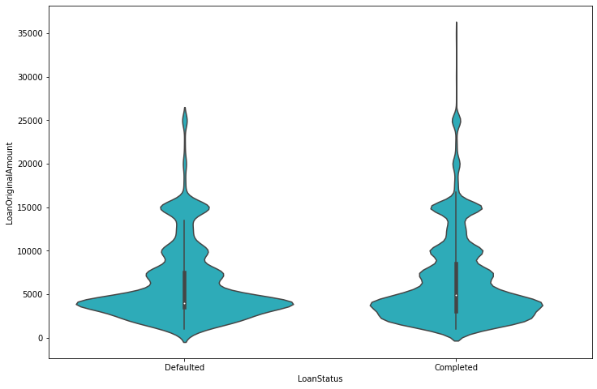

```python
plt.figure(figsize = [12, 8])
sb.violinplot(data = loan, x = 'LoanStatus', y = 'LoanOriginalAmount', color = color);
```

Defaulted credits are typically smaller than completed credits.

The Term and loan status:

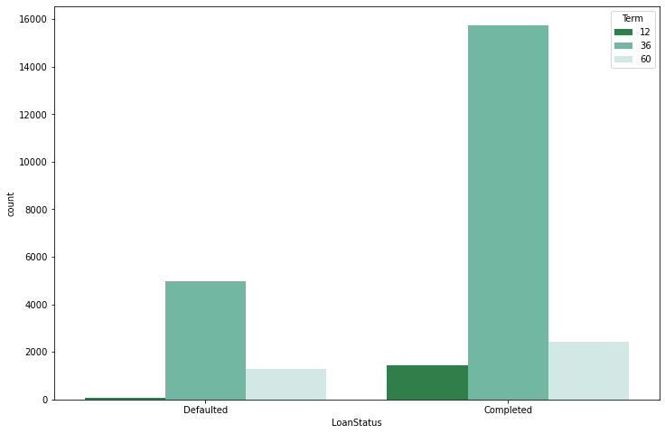

```python
plt.figure(figsize = [12, 8])
sb.countplot(data=loan, x='LoanStatus', hue='Term', palette='BuGn_r');
```

Loans with a term of 60 months have the highest proportion of delinquent credits.

Now let's look at the variables that determine Prosper rating of the Clients.

```python
loan
```

[output not shown]

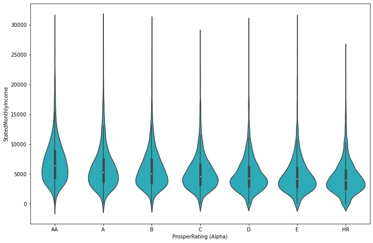

```python
plt.figure(figsize = [12, 8])
sb.violinplot(data = loan, x = 'ProsperRating (Alpha)', y = 'StatedMonthlyIncome', color = color);
```

Individuals with a larger monthly income have higher ratings.

Rating and the number of investors:

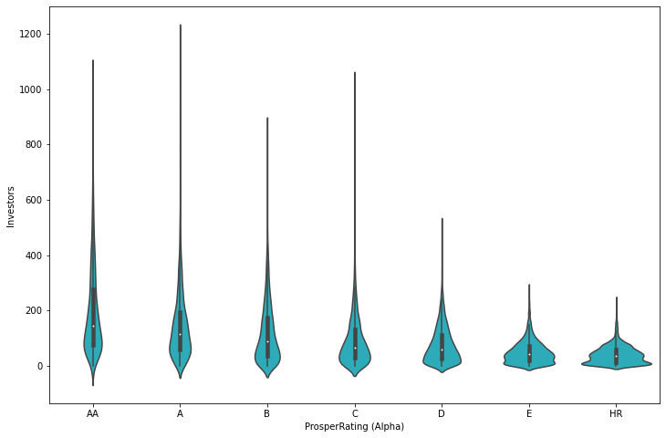

```python
plt.figure(figsize = [12, 8])
sb.violinplot(data = loan, x='ProsperRating (Alpha)', y='Investors', color = color);
```

Prosper rating and employment situation next.

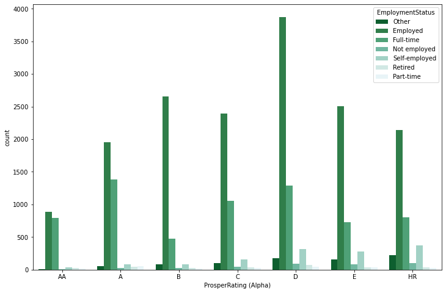

```python
plt.figure(figsize = [12, 8])
sb.countplot(data = loan, x = 'ProsperRating (Alpha)', hue = 'EmploymentStatus', palette='BuGn_r');
```

Individuals with employment status of Not Employed, Self-employed, Retired, and Part-Time appear to be have lower ratings.

Total number of delinquencies and the rating.

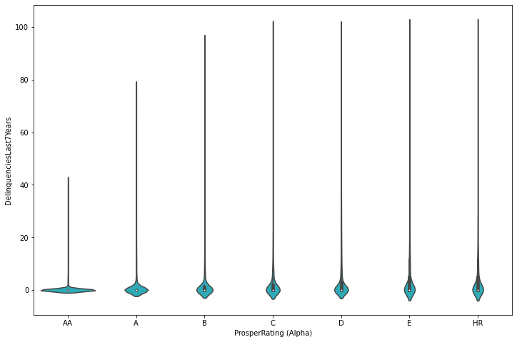

```python
plt.figure(figsize = [12, 8])
sb.violinplot(data = loan, x = 'ProsperRating (Alpha)', y = 'DelinquenciesLast7Years', color = color);
```

Indivuduals with highest AA rating tend to have less delinquencies than others.

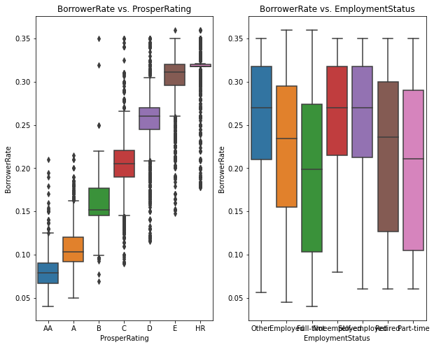

```python
plt.figure(figsize = [15,8])

plt.subplot(1, 2, 1)
sb.boxplot(data = loan, x = 'ProsperRating (Alpha)', y = 'BorrowerRate')
plt.gcf().set_size_inches(10, 8)
plt.title('BorrowerRate vs. ProsperRating')
plt.xlabel('ProsperRating')
plt.ylabel('BorrowerRate')

plt.subplot(1, 2, 2)
sb.boxplot(data = loan, x = 'EmploymentStatus', y = 'BorrowerRate')
plt.gcf().set_size_inches(10, 8)
plt.title('BorrowerRate vs. EmploymentStatus')
plt.xlabel('EmploymentStatus')
plt.ylabel('BorrowerRate');
```

### Did you observe any interesting relationships between the other features (not the main feature(s) of interest)?

> One notable observation I've made is that the prosper rating D is the most common among defaulted credits.

## Multivariate Exploration

Here we will check the relationship between Term, Rate, Delinquencies, Monthly Income, Loan Amount and Loan Status.

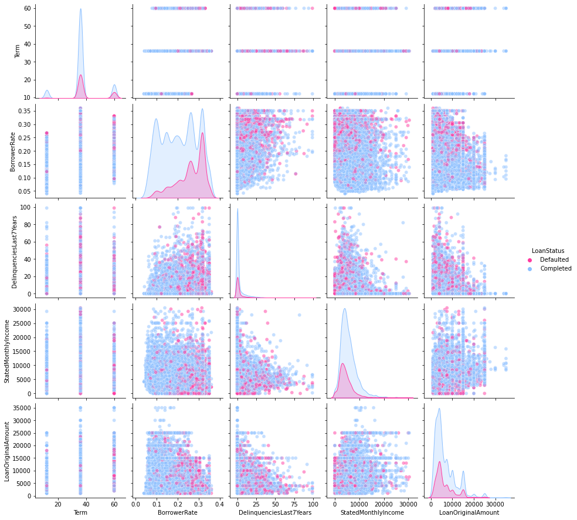

```python
# extract and visualize the features of interest
cols = [
    'Term', 'BorrowerRate', 'DelinquenciesLast7Years', 'StatedMonthlyIncome',
    'LoanOriginalAmount', 'LoanStatus'
       ]
g = sb.pairplot(loan[cols], hue='LoanStatus',
                palette={'Defaulted': '#ff3ba0', 'Completed': '#8cc0ff'},
                plot_kws={'alpha': 0.5, 'edgecolor': 'white'})
fig = g.fig;
```

Number of Delinquencies for the past 7 years and Borrower Rate appear to be the best predictors of credit outcome, however as we saw in the previous section, both are derivatives of credit rating.

We can check our categorical variables now, we start with the correlations between rating, loan amount, and loan status:

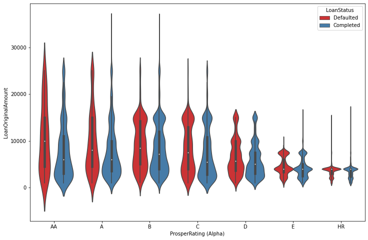

```python
plt.figure(figsize = [12, 8])
sb.violinplot(data=loan, x='ProsperRating (Alpha)', y='LoanOriginalAmount', hue='LoanStatus', palette="Set1");
```

Defaulted credits, with the exception of the lowest ratings, are usually greater than completed credits. At first glance, this contradicts what we learned in the previous section (defaulted credits are smaller than completed), but the majority of defaulted credits come from people with low Prosper ratings (who borrow less), which lowers the average amount of defaulted credit.

How the loan amount, listing category, and loan status interact:

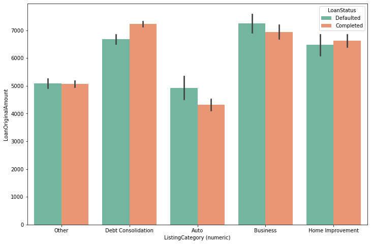

```python
plt.figure(figsize = [12, 8])
sb.barplot(data=loan, x='ListingCategory (numeric)', y='LoanOriginalAmount', hue='LoanStatus', palette="Set2");
```

Connections between credit category, credit rating, and credit outcome:

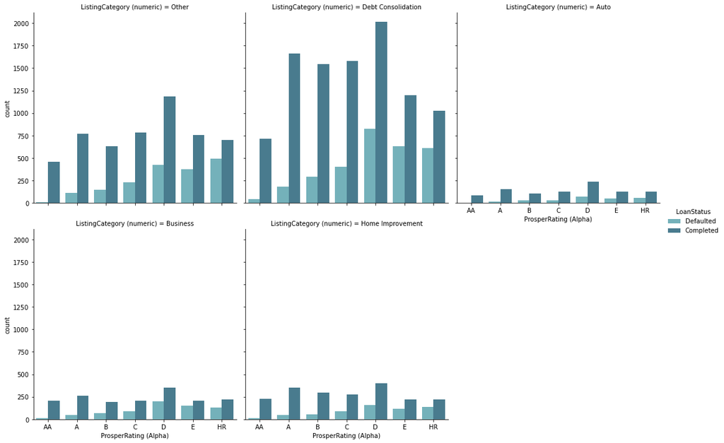

```python
sb.catplot(x='ProsperRating (Alpha)', hue='LoanStatus', col='ListingCategory (numeric)',
              data=loan, kind='count', palette='GnBu_d', col_wrap=3
             );
```

There does not appear to be a significant difference in default rates across different categories when broken down by ratings.

Relationship between the term, the category, and the result:

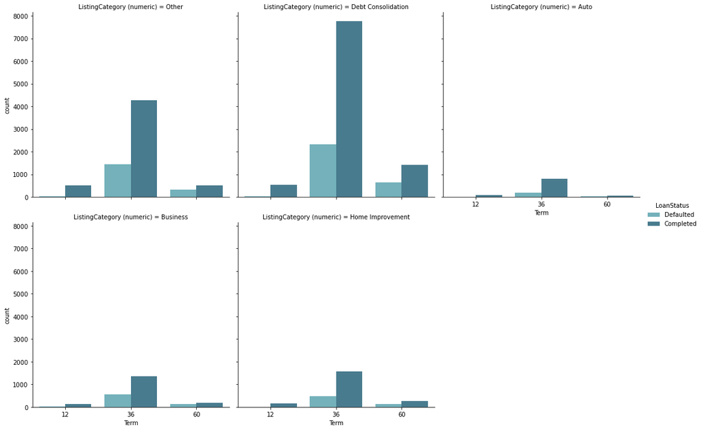

```python
sb.catplot(x='Term', hue='LoanStatus', col='ListingCategory (numeric)',
              data=loan, kind='count', palette='GnBu_d', col_wrap=3
             );
```

We can see that long-term credits are especially risky for purposes Other, Business and Home Improvement.

Relationship between Term, Rating and outcome of credit:

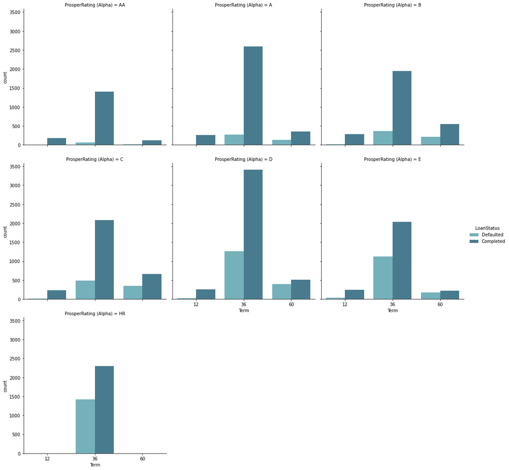

```python
sb.catplot(x='Term', hue='LoanStatus', col='ProsperRating (Alpha)',
              data=loan, kind='count', palette='GnBu_d', col_wrap=3
             );
```

Long-term credit (60 months) appears to be riskier than mid-term (36 months) or short-term credit (less than a year) (12 months). However, there are neither short-term or long-term lending options for those with the lowest credit ratings.

### Were there any interesting or surprising interactions between features?

> It was discovered that defaulted credits for people with high Prosper ratings are typically larger than fulfilled credits. Another intriguing finding is that people with the lowest rating (HR) only have mid-term (36-month) credits.